# Cyclistic RMD

2024-12-13

# Case study: How does a bike-share navigate speedy success

#### This RMarkdown document describes the different steps taken to calculate and graph:

- Ride length time mean group by “usertype” and “day_of_week”
- Number of trips per “usertype” and “day_of_week
- Correlations between these variables (grouped by “usertype”). Notes: the data used for these calculations correspond to the data tables “Divvy 2019 Q1” and “Divvy 2020 Q1” https://divvy-tripdata.s3.amazonaws.com/index.html

## *Calculations*

### 1) Upload Cyclistic 2019 and Cyclistic 2020 tables and join them

### 2) Convert start_time and end_time (as.POSIXct)

### 3) Difference between end_time and start time

### 4) Create a vector of day names corresponding to the numbers 1-7

### 5) Convert the day_of_week column to a factor with the corresponding day names

### 6) Load dplyr package for easy data manipulation

### 7) Calculate mean of ride_lengh_seconds for each “usertype” and “day_of_week”.

### 8) Convert the mean ride length (in seconds) back to HH:MM:SS

```
a) Function to convert seconds back to HH:MM:SS format
b) Ensure all values are integers and format them properly with leading zeros
```

```
## # A tibble: 14 × 4
##    usertype   day_of_week mean_ride_length mean_ride_length_time
##    <chr>      <fct>                  <dbl> <chr>
##  1 Customer   Sunday                 5061. 01:24:21
##  2 Customer   Monday                 3938. 01:05:38
##  3 Customer   Tuesday                4173. 01:09:33
##  4 Customer   Wednesday              4091. 01:08:11
##  5 Customer   Thursday               7729. 02:08:49
##  6 Customer   Friday                 5714. 01:35:13
##  7 Customer   Saturday               4951. 01:22:30
##  8 Subscriber Sunday                  973. 00:16:12
##  9 Subscriber Monday                  822. 00:13:42
## 10 Subscriber Tuesday                 722. 00:12:01
## 11 Subscriber Wednesday               712. 00:11:51
## 12 Subscriber Thursday                707. 00:11:47
## 13 Subscriber Friday                  797. 00:13:16
## 14 Subscriber Saturday                974. 00:16:14
```

### 9) Calculate number of trips for “usertype” and “day_of_week”

```
## # A tibble: 14 × 3
##    day_of_week usertype        n
##    <fct>       <chr>       <int>
##  1 Sunday      Customer    18652
##  2 Sunday      Subscriber  60197
##  3 Monday      Customer     6747
##  4 Monday      Subscriber 110430
##  5 Tuesday     Customer     7992
##  6 Tuesday     Subscriber 127973
##  7 Wednesday   Customer     8422
##  8 Wednesday   Subscriber 121903
##  9 Thursday    Customer     7815
## 10 Thursday    Subscriber 125228
## 11 Friday      Customer     8542
## 12 Friday      Subscriber 115168
## 13 Saturday    Customer    13473
## 14 Saturday    Subscriber  59413
```

## *Charts*

### 1) Bar chart mean_ride_length_time vs. day_of_week, grouped by usertype

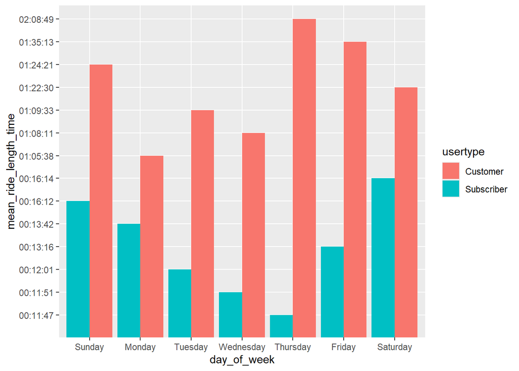

### 2) Bar chart number of trips per day vs. day_of_week, grouped by usertype

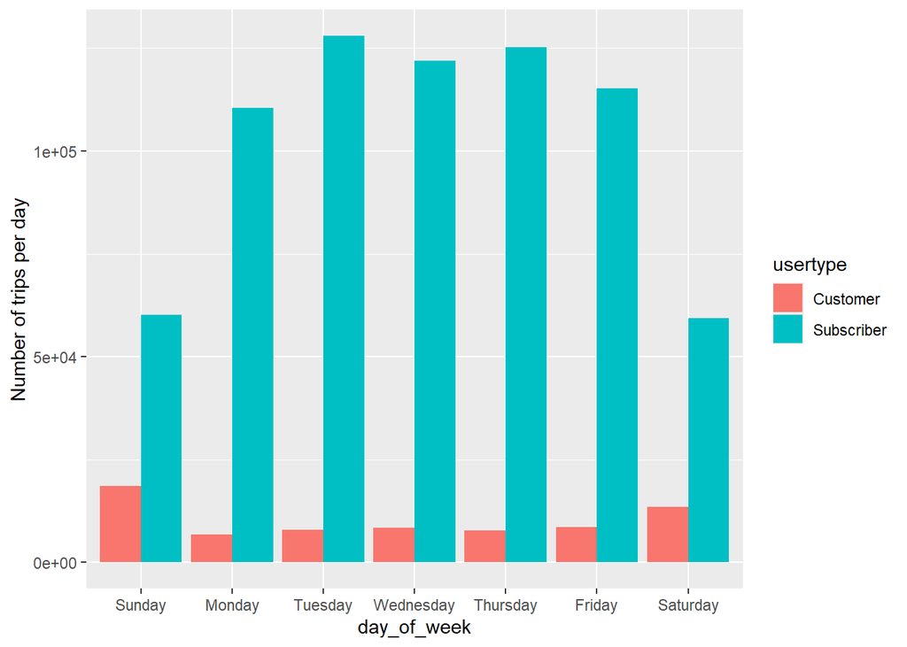

### 3) Combine data frames mean_ride_length_by_day and weekday_count_per_day

### 4) Calculate correlations between the previous two calculations, for each “usertype”

### 5) Create separate tables for each “usertype”

### 6) Create correlation chart for “Customer”

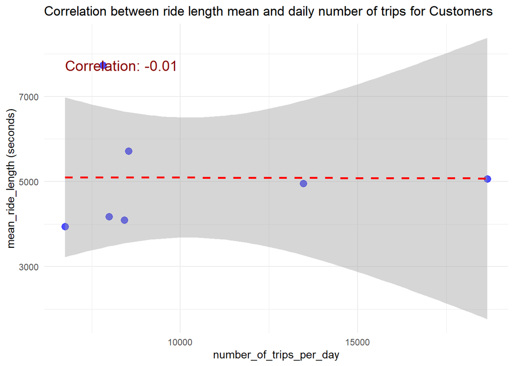

### 7) Create correlation chart for “Subscriber”

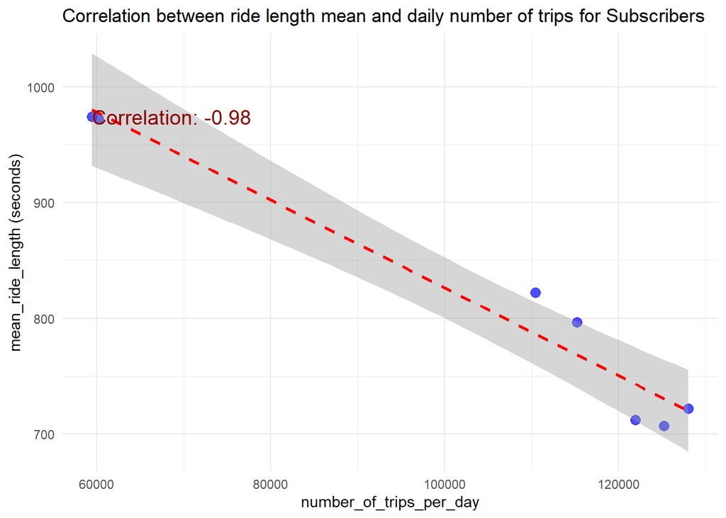